# Ordinal Logistic Regression in R

Hyundo Im

Feb 17 2018

# Ordinal Logistic Reression

```r
library(foreign)
library(tidyverse)
library(MASS)
library(Hmisc)
library(reshape2)
```

## Description of the Data

```r
dat <- read.dta("https://stats.idre.ucla.edu/stat/data/ologit.dta")
head(dat)
```

```
##             apply pared public  gpa
## 1     very likely     0      0 3.26
## 2 somewhat likely     1      0 3.21
## 3        unlikely     1      1 3.94
## 4 somewhat likely     0      0 2.81
## 5 somewhat likely     0      0 2.53
## 6        unlikely     0      1 2.59
```

### One at a time, table apply, pared, and public

```r
lapply(dat[,c("apply","pared","public")],table)
```

```
## $apply
##
##        unlikely somewhat likely     very likely
##             220             140              40
##
## $pared
##
##   0   1
## 337  63
##
## $public
##
##   0   1
## 343  57
```

### three way cross tabs (xtabs) and flatten the table

```r
ftable(xtabs(~public+apply+pared, data=dat))
```

```
##                        pared   0   1
## public apply
## 0      unlikely              175  14
##        somewhat likely        98  26
##        very likely            20  10
## 1      unlikely               25   6
##        somewhat likely        12   4
##        very likely             7   3
```

```r
summary(dat$gpa)
```

```
##    Min. 1st Qu.  Median    Mean 3rd Qu.    Max.
##   1.900   2.720   2.990   2.999   3.270   4.000
```

```r
sd(dat$gpa)
```

```
## [1] 0.3979409
```

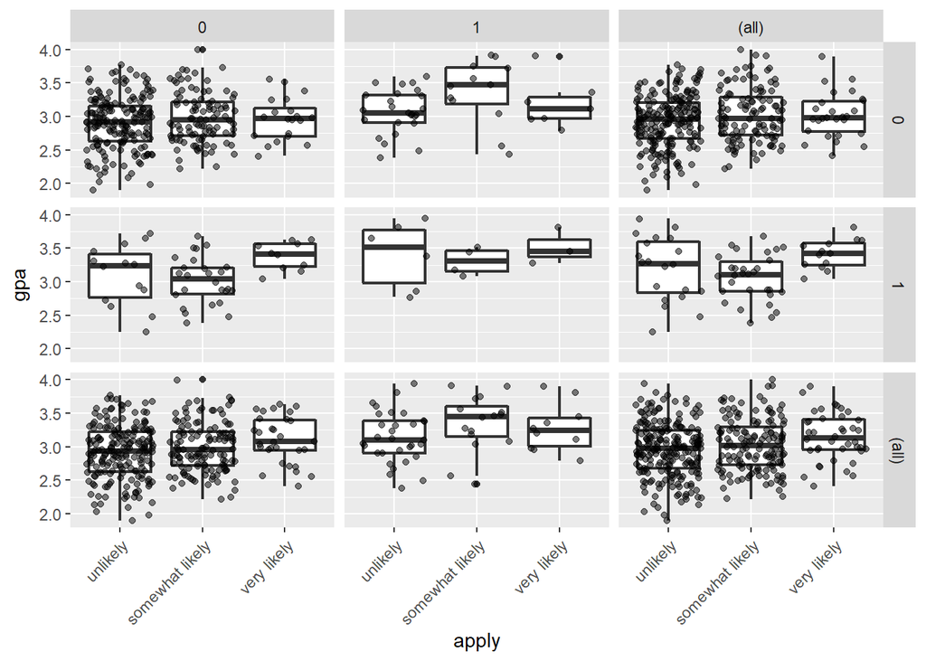

```r
dat%>%ggplot(aes(x=apply, y = gpa))+
  geom_boxplot(size=.75)+
  geom_jitter(alpha=.5)+
  facet_grid(pared~public,margins = TRUE)+
  theme(axis.text.x=element_text(angle=45,hjust=1,vjust = 1))
```

## Ordered logistic regression

use `polr` command from `MASS` packages to estimate an ordered logistic regression model.

**Assumption**: proportional odds assumption

We also specify `Hess=TRUE` to have the model return the observed information matrix from optimization (called the Hessian) which is used to get standard errors.

### fit ordered logit model and store results ‘m’

```r
m <- polr(apply~pared+public+gpa, data=dat, Hess = TRUE)

summary(m)
```

```
## Call:
## polr(formula = apply ~ pared + public + gpa, data = dat, Hess = TRUE)
##
## Coefficients:
##           Value Std. Error t value
## pared   1.04769     0.2658  3.9418
## public -0.05879     0.2979 -0.1974
## gpa     0.61594     0.2606  2.3632
##
## Intercepts:
##                             Value   Std. Error t value
## unlikely|somewhat likely     2.2039  0.7795     2.8272
## somewhat likely|very likely  4.2994  0.8043     5.3453
##
## Residual Deviance: 717.0249
## AIC: 727.0249
```

We see:

- We see the usual regression output coefficient table including the value of each coefficient, standard errors, and t value.
- We see the estimates for the two intercepts, which are sometimes called cutpoints. The intercepts indicate where the latent variable is cut to make the three groups that we observe in our data.

### Store table

```r
(ctable <- coef(summary(m)))
```

```
##                                   Value Std. Error    t value
## pared                        1.04769010  0.2657894  3.9418050
## public                      -0.05878572  0.2978614 -0.1973593
## gpa                          0.61594057  0.2606340  2.3632399
## unlikely|somewhat likely     2.20391473  0.7795455  2.8271792
## somewhat likely|very likely  4.29936315  0.8043267  5.3452947
```

```r
p <- pnorm(abs(ctable[,"t value"]), lower.tail = FALSE)*2
(ctable <- cbind(ctable,"p value" = p))
```

```
##                                   Value Std. Error    t value      p value
## pared                        1.04769010  0.2657894  3.9418050 8.087072e-05
## public                      -0.05878572  0.2978614 -0.1973593 8.435464e-01
## gpa                          0.61594057  0.2606340  2.3632399 1.811594e-02
## unlikely|somewhat likely     2.20391473  0.7795455  2.8271792 4.696004e-03
## somewhat likely|very likely  4.29936315  0.8043267  5.3452947 9.027008e-08
```

```r
(ci <- confint(m))
```

```
##             2.5 %    97.5 %
## pared   0.5281768 1.5721750
## public -0.6522060 0.5191384
## gpa     0.1076202 1.1309148
```

### odds ratios

```r
exp(coef(m))
```

```
##     pared    public       gpa
## 2.8510579 0.9429088 1.8513972
```

### OR and CI

```r
exp(cbind(OR=coef(m), ci))
```

```
##               OR     2.5 %   97.5 %
## pared  2.8510579 1.6958376 4.817114
## public 0.9429088 0.5208954 1.680579
## gpa    1.8513972 1.1136247 3.098490
```

## Assumptions

- The relationship between each pair of outcome groups is the same. In other words, ordinal logistic regression asusmes that the coefficients that describe the relationship between, say, the lowest versus all higher categories of the response variable are the same as those that describe the relationship between the next lowest category and all higher categories. This is called the **proportional odds assumption** or the **parallel regression assumption**.
- Because the relationship between all pairs of groups is the same, there is only one set of coefficients. If this was not the case, we would need different sets of coefficients in the model to describe the relationship between each pair of outcome groups.
- In order to assess the appropriateness of ourmodel, we need to evaluate whether the proportional odds assumption is tenable.
- However, Harrell does recommend a graphical method for assessing the parallel slopes assumption.

```r
sf <- function(y){
  c("Y>=1" = qlogis(mean(y>=1)),
    "Y>=2" = qlogis(mean(y>=2)),
    "Y>=3" = qlogis(mean(y>=3)))
}
(s <- with(dat,summary(as.numeric(apply)~pared+public+gpa,fun=sf)))
```

```
## as.numeric(apply)     N= 400
##
## +-------+-----------+---+----+-----------+---------+
## |       |           |N  |Y>=1|Y>=2       |Y>=3     |
## +-------+-----------+---+----+-----------+---------+
## |pared  |No         |337|Inf |-0.37833644|-2.440735|
## |       |Yes        | 63|Inf | 0.76546784|-1.347074|
## +-------+-----------+---+----+-----------+---------+
## |public |No         |343|Inf |-0.20479441|-2.345006|
## |       |Yes        | 57|Inf |-0.17589067|-1.547563|
## +-------+-----------+---+----+-----------+---------+
## |gpa    |[1.90,2.73)|102|Inf |-0.39730180|-2.772589|
## |       |[2.73,3.00)| 99|Inf |-0.26415158|-2.302585|
## |       |[3.00,3.28)|100|Inf |-0.20067070|-2.090741|
## |       |[3.28,4.00]| 99|Inf | 0.06062462|-1.803594|
## +-------+-----------+---+----+-----------+---------+
## |Overall|           |400|Inf |-0.20067070|-2.197225|
## +-------+-----------+---+----+-----------+---------+
```

The table above displays the (linear) predicted values we would get if we regressed our dependent variable on our predictor variables one at a time, witout the parallel slopes assumption.

- We can evaluate the parallel slopes assumption by running a series of binary logistic regressions with vaying cutpoints on the dependent variables and checking the equality of coefficients across cutpoints.

```r
glm(I(as.numeric(apply) >=2)~pared, family="binomial",data=dat)
```

```
##
## Call:  glm(formula = I(as.numeric(apply) >= 2) ~ pared, family = "binomial",
##     data = dat)
##
## Coefficients:
## (Intercept)        pared
##     -0.3783       1.1438
##
## Degrees of Freedom: 399 Total (i.e. Null);  398 Residual
## Null Deviance:       550.5
## Residual Deviance: 534.1     AIC: 538.1
```

```r
glm(I(as.numeric(apply)>=3)~pared,family="binomial",data=dat)
```

```
##
## Call:  glm(formula = I(as.numeric(apply) >= 3) ~ pared, family = "binomial",
##     data = dat)
##
## Coefficients:
## (Intercept)        pared
##      -2.441        1.094
##
## Degrees of Freedom: 399 Total (i.e. Null);  398 Residual
## Null Deviance:       260.1
## Residual Deviance: 252.2     AIC: 256.2
```

We can use the values in this table to help us assess whether the proportional odds assumption is reasonable for our model.

```r
s[,4] <- s[,4] - s[,3]
s[,3] <- s[,3] - s[,3]
s
```

```
## as.numeric(apply)     N= 400
##
## +-------+-----------+---+----+----+---------+
## |       |           |N  |Y>=1|Y>=2|Y>=3     |
## +-------+-----------+---+----+----+---------+
## |pared  |No         |337|Inf |0   |-2.062399|
## |       |Yes        | 63|Inf |0   |-2.112541|
## +-------+-----------+---+----+----+---------+
## |public |No         |343|Inf |0   |-2.140211|
## |       |Yes        | 57|Inf |0   |-1.371672|
## +-------+-----------+---+----+----+---------+
## |gpa    |[1.90,2.73)|102|Inf |0   |-2.375287|
## |       |[2.73,3.00)| 99|Inf |0   |-2.038434|
## |       |[3.00,3.28)|100|Inf |0   |-1.890070|
## |       |[3.28,4.00]| 99|Inf |0   |-1.864219|
## +-------+-----------+---+----+----+---------+
## |Overall|           |400|Inf |0   |-1.996554|
## +-------+-----------+---+----+----+---------+
```

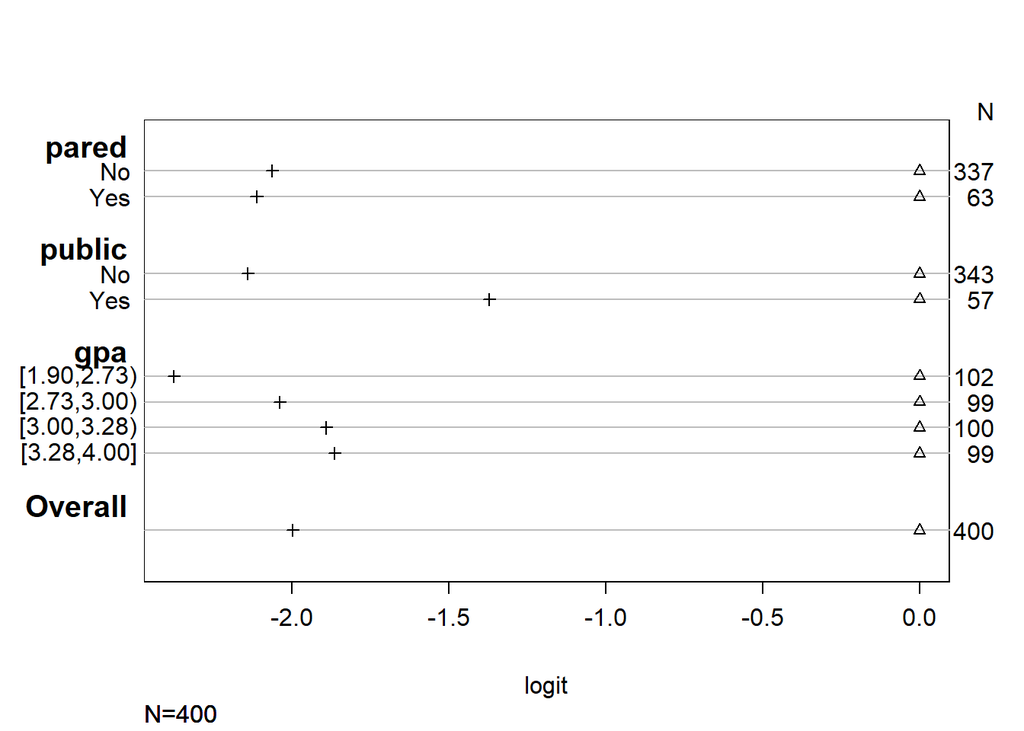

```r
plot(s, which = 1:3, pch = 1:3, xlab="logit", main=' ',
     xlim = range(s[,3:4]))
```

## Check

Once we are done assessing whether the assumptions of our model hold, we can obtain predicted probabilities, which are usually easier to understand than either the coefficients or the odds ratios.

```r
newdat <- data.frame(
  pared= rep(0:1, 200),
  public = rep(0:1, each = 200),
  gpa = rep(seq(from=1.9, to = 4, length.out = 100),4)
)
newdat <- cbind(newdat, predict(m, newdat, type= "probs"))
head(newdat)
```

```
##   pared public      gpa  unlikely somewhat likely very likely
## 1     0      0 1.900000 0.7376186       0.2204577  0.04192370
## 2     1      0 1.921212 0.4932185       0.3945673  0.11221424
## 3     0      0 1.942424 0.7325300       0.2244841  0.04298593
## 4     1      0 1.963636 0.4866885       0.3984676  0.11484395
## 5     0      0 1.984848 0.7273792       0.2285470  0.04407383
## 6     1      0 2.006061 0.4801630       0.4023098  0.11752712
```

### Reshape the data long and plot all of the predicted probabilities for the different conditions

```r
lnewdat <- melt(newdat, id.vars = c("pared","public","gpa"),
                variable.name = "Level", value.name = "Probability")
head(lnewdat)
```

```
##   pared public      gpa    Level Probability
## 1     0      0 1.900000 unlikely   0.7376186
## 2     1      0 1.921212 unlikely   0.4932185
## 3     0      0 1.942424 unlikely   0.7325300
## 4     1      0 1.963636 unlikely   0.4866885
## 5     0      0 1.984848 unlikely   0.7273792
## 6     1      0 2.006061 unlikely   0.4801630
```

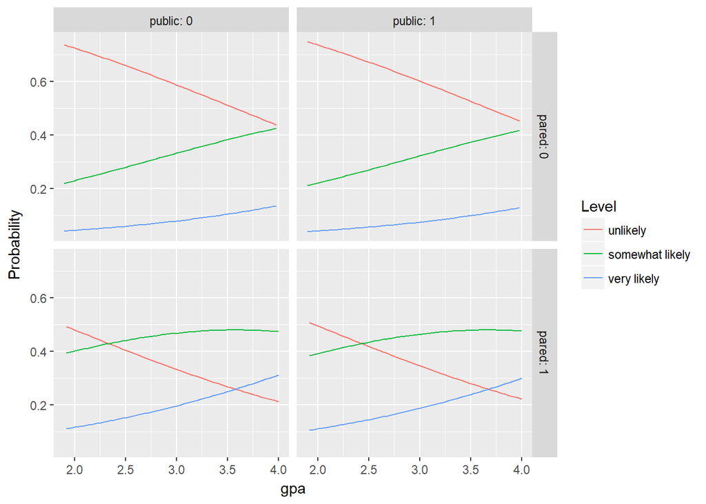

```r
lnewdat %>% ggplot(aes(x=gpa, y= Probability, colour=Level))+
  geom_line()+
  facet_grid(pared~public, labeller = "label_both")
```